# Chapter code for Applied Predictive Modeling (Kuhn and Johnson, 2013)

Chapter 14

by Brian Hassett

# 14 Classification Trees and Rule-Based Models

This is a `tidymodels` implementation of the code in **Chapter 14** of **Applied Predictive Modeling** by Max Kuhn and Kjell Johnson[^1].

The authors use the Kaggle grant data set to demonstrate the models. I have chosen to demonstrate each model on a different data set in this notebook. The data set I have used is the **Credit Approval Data Set** which is available at the UCI Machine Learning Repository[^2]. This data set is moderate in size ($n = 653$, $p = 16$). It has a binary outcome variable which is relatively balanced. There is a mixture of categorical and numeric predictors, and only a small amount of missing data.

Each model is implemented in its own section, including preprocessing and tuning. The models are then collectively assessed in the **Metrics** section, which includes ROC curves and lift/gain charts for each model.

## Setup

```r
# Load packages:
library(tidyverse)
library(tidymodels)
library(baguette)
library(rules)
library(ggcorrplot)
library(patchwork)

# Load my functions:
source("/home/brian/R/dir/Util/bh_functions.R")

# Options:
theme_set(theme_bw())
options(digits = 4)
```

## Load Data

```r
# Prepare data:
df <- read_csv("/home/brian/R/dir/APM/chapter12/data/crx.data", col_names = F, na = '?') %>%
  mutate(y = factor(X16),
         X11 = parse_number(X11),     # this should be continuous according to the description
         X14 = parse_number(X14)) %>% # this should be continuous according to the description
  # Using '+' and '-' causes problems for R so switch to simple strings;
  mutate(y = factor(if_else(y == "+", "yes", "no"), levels = c("yes", "no"))) %>%
  # convert the logical variables to factors (some models (C5.0) can't handle logicals)
  mutate(across(where(is.logical), as_factor)) %>%
  # drop the original response, X16;
  dplyr::select(y, everything(), -X16)

# Remove missing data (small amount):
df <- na.omit(df)

# View data:
df
```

| y | X1 | X2 | X3 | X4 | X5 | X6 | X7 | X8 | X9 | X10 | X11 | X12 | X13 | X14 | X15 |
| --- | --- | --- | --- | --- | --- | --- | --- | --- | --- | --- | --- | --- | --- | --- | --- |
| yes | b | 30.83 | 0.000 | u | g | w | v | 1.250 | TRUE | TRUE | 1 | FALSE | g | 202 | 0 |
| yes | a | 58.67 | 4.460 | u | g | q | h | 3.040 | TRUE | TRUE | 6 | FALSE | g | 43 | 560 |
| yes | a | 24.50 | 0.500 | u | g | q | h | 1.500 | TRUE | FALSE | 0 | FALSE | g | 280 | 824 |
| yes | b | 27.83 | 1.540 | u | g | w | v | 3.750 | TRUE | TRUE | 5 | TRUE | g | 100 | 3 |
| yes | b | 20.17 | 5.625 | u | g | w | v | 1.710 | TRUE | FALSE | 0 | FALSE | s | 120 | 0 |
| yes | b | 32.08 | 4.000 | u | g | m | v | 2.500 | TRUE | FALSE | 0 | TRUE | g | 360 | 0 |
| yes | b | 33.17 | 1.040 | u | g | r | h | 6.500 | TRUE | FALSE | 0 | TRUE | g | 164 | 31285 |
| yes | a | 22.92 | 11.585 | u | g | cc | v | 0.040 | TRUE | FALSE | 0 | FALSE | g | 80 | 1349 |
| yes | b | 54.42 | 0.500 | y | p | k | h | 3.960 | TRUE | FALSE | 0 | FALSE | g | 180 | 314 |
| yes | b | 42.50 | 4.915 | y | p | w | v | 3.165 | TRUE | FALSE | 0 | TRUE | g | 52 | 1442 |

[output cut: 643 more lines]

## Data Splitting

```r
# Splits
set.seed(1)
splits <- initial_split(df, strata = y) # default prop is 3/4
df_train <- training(splits)
df_test <- testing((splits))

# CV Folds:
set.seed(123)
folds <- vfold_cv(data = df_train, v = 5)
```

## Data Summary

```r
bh_print_data_summary(df)
```

```
                      [,1]
num_rows              "   653"
num_cols              "    16"
num_categorical_cols  "    10"
num_numeric_cols      "     6"
all_missing_cols      "     0"
complete_cols         "    16"
total_missing         "     0"
total_percent_missing "     0"
total_data_points     "10,448"
size_bytes            "82,832"
```

## Distribution of Response Class

Plot the response class:

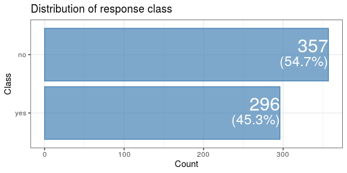

```r
df %>%
  count(y) %>%
  mutate(prop = round(100*n/sum(n), 1)) %>%
  ggplot() +
  geom_col(aes(y, n),
           fill = "steelblue", color = "steelblue", alpha = 0.7) +
  geom_text(aes(y, n, label = n), # count
            hjust = 1, vjust = -0.2, size = 8,
            color = "white") +
  geom_text(aes(y, n, label = paste0("(", prop, "%)")), # prop
            hjust = 1, vjust = 1.2, size = 6,
            color = "white") +
  labs(x = "Class", y = "Count",
       title = "Distribution of response class") +
  coord_flip()
```

The response class is relatively balanced.

## Histograms of Numeric Predictors

Plot histograms of numeric predictors:

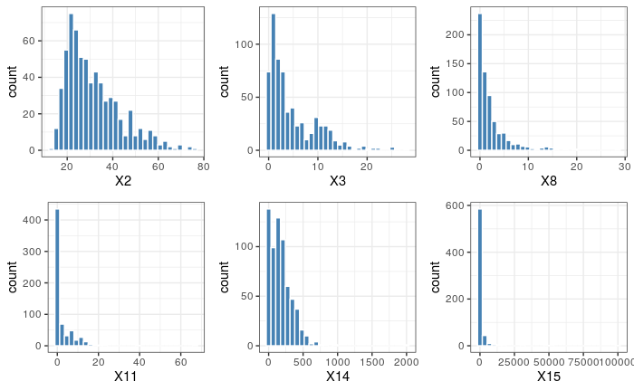

```r
bh_plot_histogram_grid(df)
```

## Bar plots of categorical variables

Plot bar plots of categorical variables:

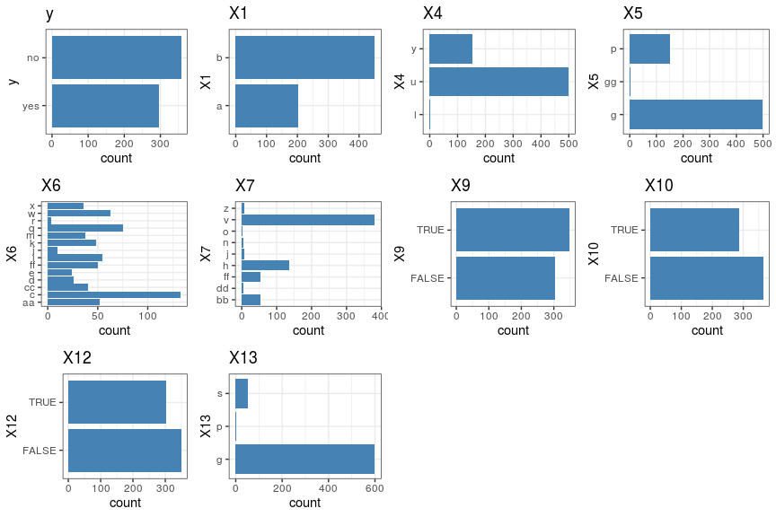

```r
bh_plot_bar_grid(df, flip = TRUE)
```

There are some sparse levels. Converting to dummy variables will likely help with this.

## Predictor Correlations

Plot the between-predictor correlations:

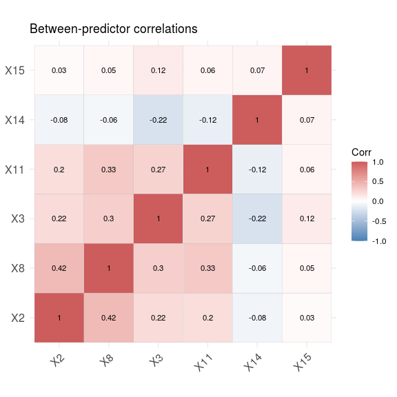

```r
correlations <- cor(df[ , bh_numeric_cols(df)])
ggcorrplot(correlations, hc.order = TRUE,
                 colors = c("steelblue", "white", "indianred"),
                 lab = TRUE, lab_size = 3, digits = 2) +
  ggtitle("Between-predictor correlations")
```

## 14.1 Basic Classification Trees

### CART Trees

#### Training data

[figure not shown]

#### Test data

```r
# Select best model:
# Use the one standard error method because the AUC drops very fast after reaching an optimum.
# The lower complexity achieves a similar performance but the AUC is more stable in the lower range.
# This might make the test performance better.
best_mod <- cart_res1 %>%
  select_by_one_std_err(cost_complexity, metric = "roc_auc")

# Update final workflow:
final_wf <-
  workflow %>%
  finalize_workflow(best_mod)

# Fit final model and make predictions:
final_fit <-
  final_wf %>%
  last_fit(splits)

# Collect predictions:
test_results <-
  final_fit %>%
  collect_predictions()
test_results$model <- "CART"
```

### J48 & C4.5

There is no implementation of J48 or C4.5 in `tidymodels` as yet.

I have implemented both of these models using `caret` in a separate notebook, `APM_14.Rmd`.

## 14.2 Rule-Based Models

There is no implementation of PART in `tidymodels` as yet.

I have implemented this model using `caret` in a separate notebook, `APM_14.Rmd`.

## 14.3 Bagged Trees

### Bagged CART Trees

#### Training data

```r
start <- bh_start_timer()
```

```
[1] "Start time: 2021-03-28 20:52:37"
```

```r
# Preprocessing
rec1 <-
  recipe(y ~ ., data = df_train) %>%
  step_center(all_numeric()) %>%
  step_scale(all_numeric()) %>%
  step_nzv(all_predictors()) %>%
  step_corr(all_numeric(), threshold = 0.9) %>%
  step_dummy(all_nominal(), -all_outcomes())

# Model
bag_mod1 <-
  bag_tree(cost_complexity = tune(), tree_depth = tune()) %>%
  set_mode("classification") %>%
  set_engine("rpart")

# Tuning grid
grid1 <- grid_regular(list(cost_complexity = cost_complexity(), tree_depth = tree_depth()), levels = 10)

# Workflow
workflow <-
  workflow() %>%
  add_model(spec = bag_mod1) %>%
  add_recipe(rec1)

# Tune
### Read in cached results if available:
file1 <- "/home/brian/R/dir/APM/chapter14/objects/bag_res1_clean.RDS"
if (file.exists(file1)) {
  bag_res1 <- readRDS(file1)
} else {
  bag_res1 <-
    workflow %>%
    tune_grid(resamples = folds, grid = grid1)
  saveRDS(bag_res1, file1)
}

end <- bh_end_timer()
```

```
[1] "End time: 2021-03-28 20:52:38"
```

```r
bh_run_time(start, end)
```

```
[1] "Run time: 0.49 secs"
```

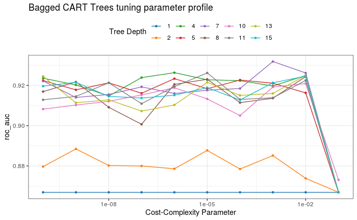

```r
# Plot AUC:
autoplot(bag_res1, metric = "roc_auc") +
  ggsci::scale_color_d3() +
  theme(legend.position = "top") +
  ggtitle("Bagged CART Trees tuning parameter profile")
```

#### Test data

```r
# Select best model:
best_mod <- bag_res1 %>%
  select_best("roc_auc")

# Update final workflow:
final_wf <-
  workflow %>%
  finalize_workflow(best_mod)

# Fit final model and make predictions:
final_fit <-
  final_wf %>%
  last_fit(splits)

# Collect predictions:
test_results <-
  rbind(
    test_results,
    cbind(
      final_fit %>%
        collect_predictions(),
      model = "Bagged Trees"
    )
  )
```

## 14.4 Random Forests

### Random Forest

#### Training data

```r
start <- bh_start_timer()
```

```
[1] "Start time: 2021-03-28 20:52:47"
```

```r
# Preprocessing
rec1 <-
  recipe(y ~ ., data = df_train) %>%
  step_center(all_numeric()) %>%
  step_scale(all_numeric()) %>%
  step_nzv(all_predictors()) %>%
  step_corr(all_numeric(), threshold = 0.9) %>%
  step_dummy(all_nominal(), -all_outcomes())

# Model
rf_mod1 <-
  rand_forest(trees = 1000, mtry = tune()) %>%
  set_mode("classification") %>%
  set_engine("randomForest")

# Tuning grid
grid1 <- data.frame(mtry = 1:(ncol(df_train) - 1))

# Workflow
workflow <-
  workflow() %>%
  add_model(spec = rf_mod1) %>%
  add_recipe(rec1)

# Tune
## Read in cached results if available:
file1 <- "/home/brian/R/dir/APM/chapter14/objects/rf_res1_clean.RDS"
if (file.exists(file1)) {
  rf_res1 <- readRDS(file1)
} else {
  rf_res1 <-
    workflow %>%
    tune_grid(resamples = folds, grid = grid1)
  saveRDS(rf_res1, file1)
}

end <- bh_end_timer()
```

```
[1] "End time: 2021-03-28 20:52:48"
```

```r
bh_run_time(start, end)
```

```
[1] "Run time: 0.58 secs"
```

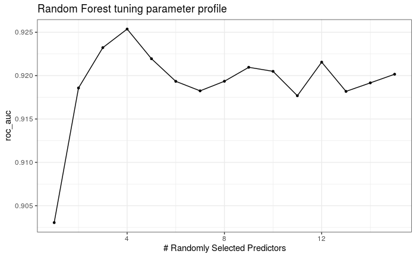

```r
# Plot AUC:
autoplot(rf_res1, metric = "roc_auc") +
  ggsci::scale_color_d3() +
  theme(legend.position = "top") +
  ggtitle("Random Forest tuning parameter profile")
```

#### Test data

```r
# Select best model:
best_mod <- rf_res1 %>%
  select_best("roc_auc")

# Update final workflow:
final_wf <-
  workflow %>%
  finalize_workflow(best_mod)

# Fit final model and make predictions:
final_fit <-
  final_wf %>%
  last_fit(splits)

# Collect predictions:
test_results <-
  rbind(
    test_results,
    cbind(
      final_fit %>%
        collect_predictions(),
      model = "Random Forest"
    )
  )
```

## 14.5 Boosting

### Boosted CART Trees

#### Training data

```r
start <- bh_start_timer()
```

```
[1] "Start time: 2021-03-28 20:52:53"
```

```r
# Preprocessing
rec1 <-
  recipe(y ~ ., data = df_train) %>%
  step_center(all_numeric()) %>%
  step_scale(all_numeric()) %>%
  step_nzv(all_predictors()) %>%
  step_corr(all_numeric(), threshold = 0.9) %>%
  step_dummy(all_nominal(), -all_outcomes())

# Model
boost_mod1 <-
  boost_tree(tree_depth = tune(), trees = tune(), learn_rate = tune()) %>%
  set_mode("classification") %>%
  set_engine("xgboost")

# Tuning grid
grid1 <- expand.grid(tree_depth = c(1, 3, 5, 7, 9),
                     trees = seq(2, 20, 2)*100,
                     learn_rate = c(0.01, 0.1))

# Workflow
workflow <-
  workflow() %>%
  add_model(spec = boost_mod1) %>%
  add_recipe(rec1)

# Tune
### Read in cached results if available:
file1 <- "/home/brian/R/dir/APM/chapter14/objects/boost_res1_clean.RDS"
if (file.exists(file1)) {
  boost_res1 <- readRDS(file1)
} else {
  boost_res1 <-
    workflow %>%
    tune_grid(resamples = folds, grid = grid1)
  saveRDS(boost_res1, file1)
}

end <- bh_end_timer()
```

```
[1] "End time: 2021-03-28 20:52:53"
```

```r
bh_run_time(start, end)
```

```
[1] "Run time: 0.49 secs"
```

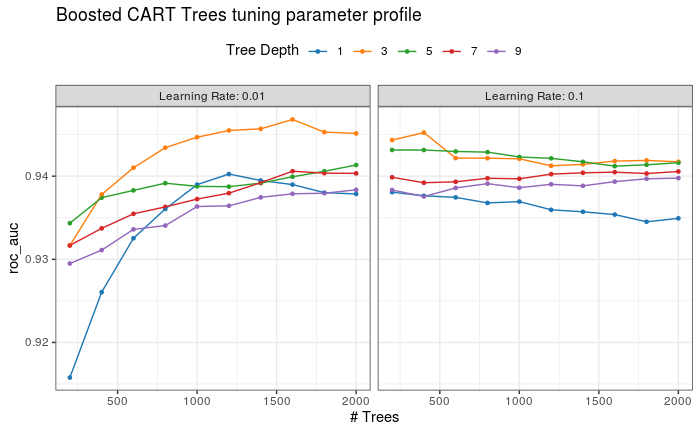

```r
# Plot AUC:
autoplot(boost_res1, metric = "roc_auc") +
  ggsci::scale_color_d3() +
  theme(legend.position = "top") +
  ggtitle("Boosted CART Trees tuning parameter profile")
```

#### Test data

```r
# Select best model:
best_mod <- boost_res1 %>%
  select_best("roc_auc")

# Update final workflow:
final_wf <-
  workflow %>%
  finalize_workflow(best_mod)

# Fit final model and make predictions:
final_fit <-
  final_wf %>%
  last_fit(splits)

# Collect predictions:
test_results <-
  rbind(
    test_results,
    cbind(
      final_fit %>%
        collect_predictions(),
      model = "Boosted Trees"
    )
  )
```

## 14.6 C5.0

### C5.0

None of the parameters in the `rules::C5_rules()` function are the same as the ones in the `caret` “C5.0” method. I have tuned across the two available parameters, `trees` and `min_n`.

#### Training data

```r
start <- bh_start_timer()
```

```
[1] "Start time: 2021-03-28 20:53:00"
```

```r
# Preprocessing
rec1 <-
  recipe(y ~ ., data = df_train) %>%
  step_center(all_numeric()) %>%
  step_scale(all_numeric()) %>%
  step_nzv(all_predictors()) %>%
  step_corr(all_numeric(), threshold = 0.9) %>%
  step_dummy(all_nominal(), -all_outcomes())

# Model
C5_mod1 <-
  C5_rules(trees = tune(), min_n = tune()) %>%
  set_mode("classification")

# Tuning grid
grid1 <- expand_grid(trees = seq(10, 100, 10), min_n = c(2, 10, 20, 40, 60, 80))

# Workflow
workflow <-
  workflow() %>%
  add_model(spec = C5_mod1) %>%
  add_recipe(rec1)

# Tune
### Read in cached results if available:
file1 <- "/home/brian/R/dir/APM/chapter14/objects/C5_res1_clean.RDS"
if (file.exists(file1)) {
  C5_res1 <- readRDS(file1)
} else {
  C5_res1 <-
    workflow %>%
    tune_grid(resamples = folds, grid = grid1)
  saveRDS(C5_res1, file1)
}

end <- bh_end_timer()
```

```
[1] "End time: 2021-03-28 20:53:01"
```

```r
bh_run_time(start, end)
```

```
[1] "Run time: 0.6 secs"
```

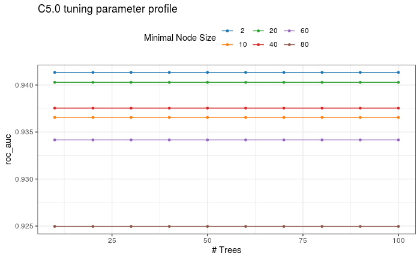

```r
# Plot AUC:
autoplot(C5_res1, metric = "roc_auc") +
  ggsci::scale_color_d3() +
  theme(legend.position = "top") +
  ggtitle("C5.0 tuning parameter profile")
```

#### Test data

```r
# Select best model:
best_mod <- C5_res1 %>%
  select_best("roc_auc")

# Update final workflow:
final_wf <-
  workflow %>%
  finalize_workflow(best_mod)

# Fit final model and make predictions:
final_fit <-
  final_wf %>%
  last_fit(splits)

# Collect predictions:
test_results <-
  rbind(
    test_results,
    cbind(
      final_fit %>%
        collect_predictions(),
      model = "C5.0"
    )
  )
```

## Metrics

### Calculate metrics

```r
get_metrics <- function(test_results, model) {
  test_results <- test_results %>%
    filter(model == {{ model }})

  metrics <- caret::confusionMatrix(data = test_results$.pred_class,
                                    reference = test_results$y,
                                    positive = "yes")

  metrics$auc <-
    test_results %>%
    yardstick::roc_auc(y, .pred_yes, event_level = "first") %>% # *1
    pluck(".estimate")

  return(metrics)
}

models <- unique(test_results$model)
metrics <- map(models, ~get_metrics(test_results, .x)) %>%
  set_names(models)

# *1: event_level not required but added for clarity. It refers to the first level in the levels of the response. Since "yes" is the target and the first level, I have set those arguments here. It was different for the churn model in APM_12_exercise_12.3.Rmd because "yes" was the second level but the important thing is to be consistent. Same thing with the ROC curves and lift/gain charts below.
```

### Inspect metrics

#### AUC

Area under ROC curve:

```r
# Display a named list of metrics as a table as opposed to a vector:
bh_display_metric <- function(metrics, type = "Metric") { # metrics is a named vector of doubles
  M <- matrix(metrics)
  dimnames(M) <- list(names(metrics), type)
  return(M)
}
bh_display_metric(map_dbl(metrics, ~.x$auc) %>% sort(decreasing = T), type = "Test AUC")
```

```
              Test AUC
Boosted Trees   0.9302
Random Forest   0.9276
Bagged Trees    0.9138
C5.0            0.9043
CART            0.9004
```

#### Accuracy

```r
bh_display_metric(map_dbl(metrics, ~.x$overall[1]) %>% sort(decreasing = T), type = "Test Accuracy")
```

```
              Test Accuracy
Boosted Trees        0.8834
Random Forest        0.8589
C5.0                 0.8589
CART                 0.8466
Bagged Trees         0.8466
```

#### Sensitivity

```r
bh_display_metric(map_dbl(metrics, ~.x$byClass[1]) %>% sort(decreasing = T), type = "Test Sensitivity")
```

```
              Test Sensitivity
Bagged Trees            0.8784
Boosted Trees           0.8649
CART                    0.8378
C5.0                    0.8378
Random Forest           0.8243
```

### ROC Curves

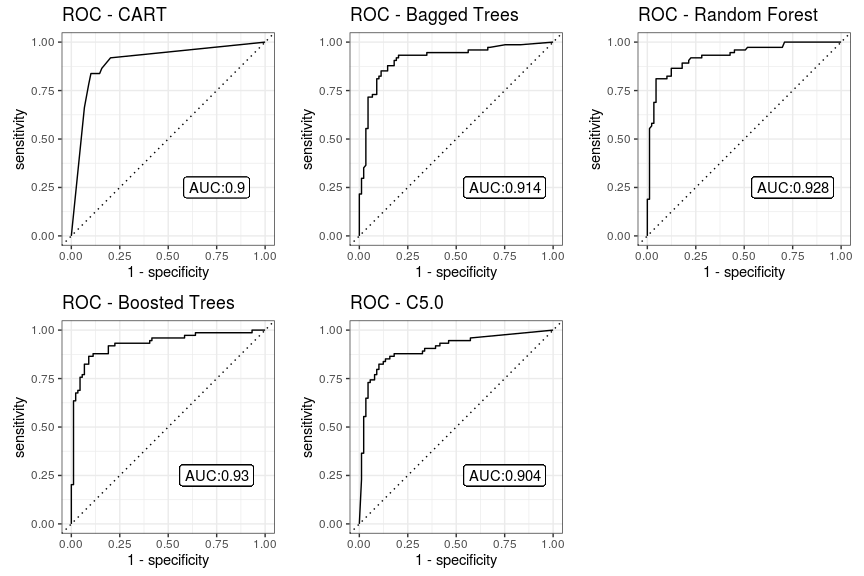

```r
# Returns an ROC curve for a given model:
plot_roc_curve <- function(test_results, model) {

  # Get AUC for labeling the plot:
  auc <- metrics[[{{ model }}]]$auc

  # ROC curve:
  p <- test_results %>%
    filter(model == {{ model }}) %>%
    yardstick::roc_curve(y, .pred_yes, event_level = "first") %>%
    autoplot() +
    geom_label(aes(x = 0.75, y = 0.25, label = paste0("AUC:", round(auc, 3)))) +
    ggtitle(paste0("ROC - ", {{ model }}))
  return(p)
}

cowplot::plot_grid(
  plotlist = map(models, ~plot_roc_curve(test_results, .x))
)
```

### Gain Curves

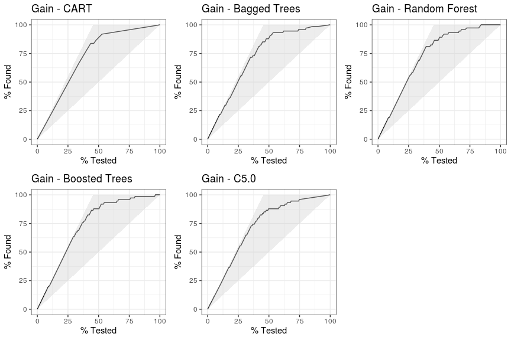

```r
# Returns a gain curve for a given model:
plot_gain_curve <- function(test_results, model) {

  # Gain curve:
  p <- test_results %>%
    filter(model == {{ model }}) %>%
    yardstick::gain_curve(y, .pred_yes, event_level = "first") %>%
    autoplot() +
    ggtitle(paste0("Gain - ", {{ model }}))
  return(p)
}

cowplot::plot_grid(
  plotlist = map(models, ~plot_gain_curve(test_results, .x))
)
```

### Lift Curves

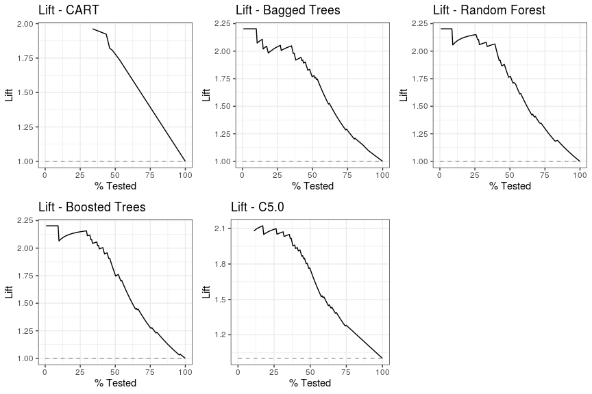

```r
# Returns a lift curve for a given model:
plot_lift_curve <- function(test_results, model) {

  # Lift curve:
  p <- test_results %>%
    filter(model == {{ model }}) %>%
    yardstick::lift_curve(y, .pred_yes, event_level = "first") %>%
    autoplot() +
    ggtitle(paste0("Lift - ", {{ model }}))
  return(p)
}

cowplot::plot_grid(
  plotlist = map(models, ~plot_lift_curve(test_results, .x))
)
```

[^1]: Kuhn M, Johnson K (2013). *Applied Predictive Modeling*. Springer.
[^2]: https://archive.ics.uci.edu/ml/datasets/Credit+Approval